# 11 Two-way ANOVA

**TipLearning outcomes**

**Questions**

- When is the use of a two-way ANOVA appropriate?
- How do I perform this in R?

**Objectives**

- Be able to perform a two-way ANOVA in R
- Understand the concept of interaction between two predictor variables
- Be able to plot interactions in R

## 11.1 Libraries and functions

**NoteClick to expand**

**R**

### 11.1.1 Libraries

```r
# A collection of R packages designed for data science
library(tidyverse)

# Converts stats functions to a tidyverse-friendly format
library(rstatix)

# Creates diagnostic plots using ggplot2
library(ggResidpanel)
```

### 11.1.2 Functions

```r
# Creates diagnostic plots
ggResidpanel::resid_panel()

# Creates a linear model
stats::lm()

# Creates an ANOVA table for a linear model
stats::anova()
```

**Python**

### 11.1.3 Libraries

```python
# A Python data analysis and manipulation tool
import pandas as pd

# Python equivalent of `ggplot2`
from plotnine import *

# Statistical models, conducting tests and statistical data exploration
import statsmodels.api as sm

# Convenience interface for specifying models using formula strings and DataFrames
import statsmodels.formula.api as smf

# Custom Python script for diagnostic plots, load from base working directory
from dgplots import dgplots
```

### 11.1.4 Functions

```python
# Summary statistics
pandas.DataFrame.describe()

# Plots the first few rows of a DataFrame
pandas.DataFrame.head()

# Reads in a .csv file
pandas.DataFrame.read_csv()

# Creates a model from a formula and data frame
statsmodels.formula.api.ols()

# Creates an ANOVA table for one or more fitted linear models
statsmodels.stats.anova.anova_lm()

# Custom function to create diagnostic plots
dgplots()
```

Note: you can download the `dgplots` script here.

## 11.2 Purpose and aim

A two-way analysis of variance is used when we have two categorical predictor variables (or factors) and a single continuous response variable. For example, when we are looking at how body `weight` (continuous response variable in kilograms) is affected by sex (categorical variable, `male` or `female`) and `exercise` type (categorical variable, `control` or `runner`).

[figure not shown]

When analysing these type of data there are two things we want to know:

1. Does either of the predictor variables have an effect on the response variable i.e. does sex affect body weight? Or does being a runner affect body weight?
2. Is there any **interaction** between the two predictor variables? An interaction would mean that the effect that exercise has on your weight depends on whether you are male or female rather than being independent of your sex. For example if being male means that runners weigh more than non-runners, but being female means that runners weight less than non-runners then we would say that there was an interaction.

We will first consider how to visualise the data before then carrying out an appropriate statistical test.

## 11.3 Data and hypotheses

We will recreate the example analysis used in the lecture. The data are stored as a `.csv` file called `data/CS4-exercise.csv`.

## 11.4 Summarise and visualise

`exercise` is a data frame with three variables; `weight`, `sex` and `exercise.` `weight` is the continuous response variable, whereas `sex` and `exercise` are the categorical predictor variables.

**R**

First, we read in the data:

```r
exercise <- read_csv("data/CS4-exercise.csv")
```

You can visualise the data with:

```r
# visualise the data, sex vs weight
ggplot(exercise,
       aes(x = sex, y = weight)) +
  geom_boxplot()
```

[figure not shown]

```r
# visualise the data, exercise vs weight
ggplot(exercise,
       aes(x = exercise, y = weight)) +
  geom_boxplot()
```

[figure not shown]

**Python**

First, we read in the data:

```python
exercise_py = pd.read_csv("data/CS4-exercise.csv")
```

You can visualise the data with:

```python
# visualise the data, sex vs weight
p = (ggplot(exercise_py,
        aes(x = "sex", y = "weight")) +
  geom_boxplot())

p.show()
```

[figure not shown]

```python
# visualise the data, exercise vs weight
p = (ggplot(exercise_py,
        aes(x = "exercise", y = "weight")) +
  geom_boxplot())

p.show()
```

[figure not shown]

These produce box plots showing the response variable (`weight`) only in terms of one of the predictor variables. The values of the other predictor variable in each case aren’t taken into account.

A better way would be to visualise both variables at the same time. We can do this as follows:

**R**

```r
ggplot(exercise,
       aes(x = sex, y = weight, fill = exercise)) +
  geom_boxplot() +
  scale_fill_brewer(palette = "Dark2")
```

[figure not shown]

This produces box plots for all (four) combinations of the predictor variables. We are plotting `sex` on the x-axis; `weight` on the y-axis and filling the box plot by `exercise` regime.

Here I’ve also changed the default colouring scheme, by using `scale_fill_brewer(palette = "Dark2")`. This uses a colour-blind friendly colour palette (more about the Brewer colour pallete [here](https://ggplot2.tidyverse.org/reference/scale_brewer.html)).

**Python**

```python
p = (ggplot(exercise_py,
        aes(x = "sex",
            y = "weight", fill = "exercise")) +
     geom_boxplot() +
     scale_fill_brewer(type = "qual", palette = "Dark2"))

p.show()
```

[figure not shown]

This produces box plots for all (four) combinations of the predictor variables. We are plotting `sex` on the x-axis; `weight` on the y-axis and filling the box plot by `exercise` regime.

Here I’ve also changed the default colouring scheme, by using `scale_fill_brewer(type = "qual", palette = "Dark2")`. This uses a colour-blind friendly colour palette (more about the Brewer colour pallete [here](https://ggplot2.tidyverse.org/reference/scale_brewer.html)).

In this example there are only four box plots and so it is relatively easy to compare them and look for any interactions between variables, but if there were more than two groups per categorical variable, it would become harder to spot what was going on.

To compare categorical variables more easily we can just plot the group means which aids our ability to look for interactions and the main effects of each predictor variable. This is called an **interaction plot**.

Create an interaction plot:

**R**

We’re adding a bit of jitter to the data, to avoid too much overlap between the data points. We can do this with `geom_jitter()`.

```r
ggplot(exercise,
       aes(x = sex, y = weight,
           colour = exercise, group = exercise)) +
  geom_jitter(width = 0.05) +
  stat_summary(fun = mean, geom = "point", size = 3) +
  stat_summary(fun = mean, geom = "line") +
  scale_colour_brewer(palette = "Dark2")
```

[figure not shown]

Here we plot `weight` on the y-axis, by `sex` on the x-axis.

- we `colour` the data by `exercise` regime and `group` the data by `exercise` to work out the mean values of each group
- `geom_jitter(width = 0.05)` displays the data, with a tiny bit of random noise, to separate the data points a bit for visualisation
- `stat_summary(fun = mean)`calculates the mean for each group
- `scale_colour_brewer()` lets us define the colour palette

The choice of which categorical factor is plotted on the horizontal axis and which is plotted as different lines is completely arbitrary. Looking at the data both ways shouldn’t add anything but often you’ll find that you prefer one plot to another.

Plot the interaction plot the other way round:

```r
ggplot(exercise,
       aes(x = exercise, y = weight,
           colour = sex, group = sex)) +
  geom_jitter(width = 0.05) +
  stat_summary(fun = mean, geom = "point", size = 3) +
  stat_summary(fun = mean, geom = "line") +
  scale_colour_brewer(palette = "Dark2")
```

[figure not shown]

**Python**

We’re adding a bit of jitter to the data, to avoid too much overlap between the data points. We can do this with `geom_jitter()`.

```python
p = (ggplot(exercise_py,
        aes(x = "sex", y = "weight",
            colour = "exercise", group = "exercise")) +
     geom_jitter(width = 0.05) +
     stat_summary(fun_data = "mean_cl_boot",
                  geom = "point", size = 3) +
     stat_summary(fun_data = "mean_cl_boot",
                  geom = "line") +
     scale_colour_brewer(type = "qual", palette = "Dark2"))

p.show()
```

[figure not shown]

Here we plot `weight` on the y-axis, by `sex` on the x-axis.

- we `colour` the data by `exercise` regime and `group` the data by `exercise` to work out the mean values of each group
- `geom_jitter(width = 0.05)` displays the data, with a tiny bit of random noise, to separate the data points a bit for visualisation
- `stat_summary(fun_data = "mean_cl_boot")`calculates the mean for each group
- `scale_colour_brewer()` lets us define the colour palette

The choice of which categorical factor is plotted on the horizontal axis and which is plotted as different lines is completely arbitrary. Looking at the data both ways shouldn’t add anything but often you’ll find that you prefer one plot to another.

Plot the interaction plot the other way round:

```python
p = (ggplot(exercise_py,
        aes(x = "exercise", y = "weight",
            colour = "sex", group = "sex")) +
     geom_jitter(width = 0.05) +
     stat_summary(fun_data = "mean_cl_boot",
                  geom = "point", size = 3) +
     stat_summary(fun_data = "mean_cl_boot",
                  geom = "line") +
  scale_colour_brewer(type = "qual", palette = "Dark2"))

p.show()
```

[figure not shown]

By now you should have a good feeling for the data and could already provide some guesses to the following three questions:

- Does there appear to be any interaction between the two categorical variables?
- If not:
  - Does `exercise` have an effect on `weight`?
  - Does `sex` have an effect on `weight`?

We can now attempt to answer these three questions more formally using an ANOVA test. We have to test for three things: the interaction, the effect of `exercise` and the effect of `sex.`

## 11.5 Assumptions

Before we can formally test these things we first need to define the model and check the underlying assumptions. We use the following code to define the model:

**R**

```r
# define the linear model
lm_exercise <- lm(weight ~ sex + exercise + sex:exercise,
                  data = exercise)
```

The `sex:exercise` term is how R represents the concept of an interaction between these two variables.

**Python**

```python
# create a linear model
model = smf.ols(formula = "weight ~ exercise * sex", data = exercise_py)
# and get the fitted parameters of the model
lm_exercise_py = model.fit()
```

The formula `weight ~ exercise * sex` can be read as “`weight` depends on `exercise` and `sex` *and* the interaction between `exercise` and `sex`.

As the two-way ANOVA is a type of linear model we need to satisfy pretty much the same assumptions as we did for a simple linear regression or a one-way ANOVA:

1. The data must not have any systematic pattern to it
2. The residuals must be normally distributed
3. The residuals must have homogeneity of variance
4. The fit should not depend overly much on a single point (no point should have high leverage).

Again, we will check these assumptions visually by producing four key diagnostic plots.

**R**

```r
resid_panel(lm_exercise,
            plots = c("resid", "qq", "ls", "cookd"),
            smoother = TRUE)
```

[figure not shown]

- The Residual plot shows the residuals against the predicted values. There is no systematic pattern here and this plot is pretty good.
- The Q-Q plot allows a visual inspection of normality. Again, this looks OK (not perfect but OK).
- The Location-Scale plot allows us to investigate whether there is homogeneity of variance. This plot is fine (not perfect but fine).
- The Cook’s D plot shows that no individual point has a high influence on the model (all values are well below 0.5)

There is a shorthand way of writing:

`weight ~ sex + exercise + sex:exercise`

If you use the following syntax:

`weight ~ sex * exercise`

Then R interprets it exactly the same way as writing all three terms. You can see this if you compare the output of the following two commands:

```r
anova(lm(weight ~ sex + exercise + sex:exercise,
         data = exercise))
```

```
Analysis of Variance Table

Response: weight
              Df Sum Sq Mean Sq F value    Pr(>F)
sex            1 4510.1  4510.1 366.911 < 2.2e-16 ***
exercise       1 1312.0  1312.0 106.733 < 2.2e-16 ***
sex:exercise   1  404.4   404.4  32.902 4.889e-08 ***
Residuals    156 1917.6    12.3
---
Signif. codes:  0 '***' 0.001 '**' 0.01 '*' 0.05 '.' 0.1 ' ' 1
```

```r
anova(lm(weight ~ sex * exercise,
         data = exercise))
```

```
Analysis of Variance Table

Response: weight
              Df Sum Sq Mean Sq F value    Pr(>F)
sex            1 4510.1  4510.1 366.911 < 2.2e-16 ***
exercise       1 1312.0  1312.0 106.733 < 2.2e-16 ***
sex:exercise   1  404.4   404.4  32.902 4.889e-08 ***
Residuals    156 1917.6    12.3
---
Signif. codes:  0 '***' 0.001 '**' 0.01 '*' 0.05 '.' 0.1 ' ' 1
```

**Python**

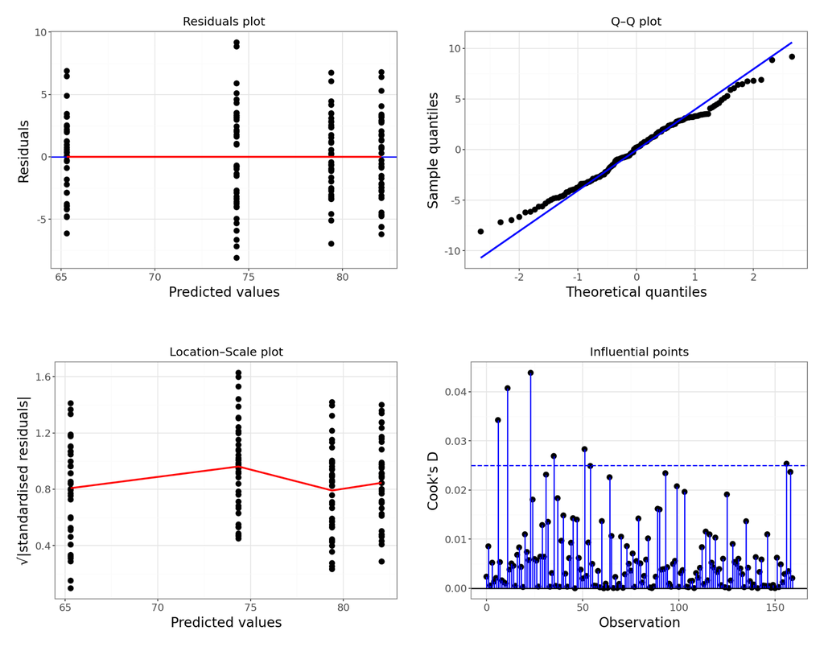

```python
dgplots(lm_exercise_py)
```

## 11.6 Implement and interpret test

The assumptions appear to be met well enough, meaning we can implement the ANOVA. We do this as follows (this is probably the easiest bit!):

**R**

```r
# perform the ANOVA
anova(lm_exercise)
```

```
Analysis of Variance Table

Response: weight
              Df Sum Sq Mean Sq F value    Pr(>F)
sex            1 4510.1  4510.1 366.911 < 2.2e-16 ***
exercise       1 1312.0  1312.0 106.733 < 2.2e-16 ***
sex:exercise   1  404.4   404.4  32.902 4.889e-08 ***
Residuals    156 1917.6    12.3
---
Signif. codes:  0 '***' 0.001 '**' 0.01 '*' 0.05 '.' 0.1 ' ' 1
```

We have a row in the table for each of the different effects that we’ve asked R to consider. The last column is the important one as this contains the p-values. We need to look at the interaction row first.

**Python**

```python
sm.stats.anova_lm(lm_exercise_py, typ = 2)
```

```
                   sum_sq     df           F        PR(>F)
exercise      1311.970522    1.0  106.733448  2.177106e-19
sex           4636.450232    1.0  377.191645  1.760076e-43
exercise:sex   404.434414    1.0   32.902172  4.889216e-08
Residual      1917.556353  156.0         NaN           NaN
```

We have a row in the table for each of the different effects that we’ve asked Python to consider. The last column is the important one as this contains the p-values. We need to look at the interaction row first.

`sex:exercise` has a p-value of about 4.89e-08 (which is smaller than 0.05) and so we can conclude that the interaction between `sex` and `exercise` is significant.

**This is where we must stop.**

The top two lines (corresponding to the effects of `sex` and `exercise`) are meaningless now. This is because the interaction means that we cannot interpret the main effects independently.

In this case, `weight` depends on *and* the sex *and* the exercise regime. This means the effect of `sex` on `weight` is dependent on `exercise` (and vice-versa).

We would report this as follows:

> A two-way ANOVA test showed that there was a significant interaction between the effects of sex and exercise on weight (p = 4.89e-08). Exercise was associated with a small loss of weight in males but a larger loss of weight in females.

## 11.7 Exercises

### 11.7.1 Auxin response

**ExerciseExercise 1**

Level:

Plant height responses to auxin in different genotypes

These `data/CS4-auxin.csv` data are from a simulated experiment that looks at the effect of the plant hormone auxin on plant height.

The experiment consists of two genotypes: a wild type control and a mutant (`genotype`). The plants are treated with auxin at different concentrations: `none`, `low` and `high`, which are stored in the `concentration` column.

The response variable plant height (`plant_height`) is then measured at the end of their life cycle, in centimeters.

Questions to answer:

- Visualise the data using boxplots and interaction plots.
- Does there appear to be any interaction between `genotype` and `concentration`?
- Carry out a two-way ANOVA test.
- Check the assumptions.
- What can you conclude? (Write a sentence to summarise).

**AnswerAnswer**

## 11.8 Answer

**R**

#### Load the data

```r
# read in the data
auxin_response <- read_csv("data/CS4-auxin.csv")

# let's have a peek at the data
head(auxin_response)
```

```
# A tibble: 6 × 3
  genotype concentration plant_height
  <chr>    <chr>                <dbl>
1 control  high                  33.7
2 control  high                  27.1
3 control  high                  22.9
4 control  high                  28.7
5 control  high                  30.7
6 control  high                  26.9
```

#### Visualise the data

```r
ggplot(auxin_response,
       aes(x = genotype, y = plant_height)) +
  geom_boxplot()
```

[figure not shown]

```r
ggplot(auxin_response,
       aes(x = concentration, y = plant_height)) +
  geom_boxplot()
```

[figure not shown]

Let’s look at the interaction plots. We’re only plotting the mean values here, but feel free to explore the data itself by adding another `geom_`.

```r
# by genotype
ggplot(auxin_response,
       aes(x = concentration,
          y = plant_height,
          colour = genotype, group = genotype)) +
  stat_summary(fun = mean, geom = "point", size = 3) +
  stat_summary(fun = mean, geom = "line") +
  geom_jitter(alpha = 0.3, width = 0.1) +
  scale_colour_brewer(palette = "Dark2")
```

[figure not shown]

```r
# by concentration
ggplot(auxin_response,
       aes(x = genotype,
           y = plant_height,
           colour = concentration, group = concentration)) +
  stat_summary(fun = mean, geom = "point", size = 3) +
  stat_summary(fun = mean, geom = "line") +
  geom_jitter(alpha = 0.3, width = 0.1) +
  scale_colour_brewer(palette = "Dark2")
```

[figure not shown]

We’ve constructed both box plots and two interaction plots. We only needed to do one interaction plot but I find it can be quite useful to look at the data from different angles.

The interaction plots show the mean values for each group, so I prefer to overlay this with the actual data. Both interaction plots suggest that there is an interaction here as the lines in the plots aren’t parallel. Looking at the interaction plot with `concentration` on the x-axis, it appears that there is non-difference between genotypes when the concentration is `low`, but that there is a difference between genotypes when the concentration is `none` or `high`.

#### Assumptions

First we need to define the model:

```r
# define the linear model, with interaction term
lm_auxin <- lm(plant_height ~ concentration * genotype,
               data = auxin_response)
```

Next, we check the assumptions:

```r
resid_panel(lm_auxin,
            plots = c("resid", "qq", "ls", "cookd"),
            smoother = TRUE)
```

[figure not shown]

So, these actually all look pretty good, with the data looking normally distributed (**Q-Q plot**), linearity OK (**Residual plot**), homogeneity of variance looking sharp (**Location-scale plot**) and no clear influential points (**Cook’s D plot**).

#### Implement the test

Let’s carry out a two-way ANOVA:

```r
# perform the ANOVA
anova(lm_auxin)
```

```
Analysis of Variance Table

Response: plant_height
                        Df Sum Sq Mean Sq F value    Pr(>F)
concentration            2 4708.2 2354.12 316.333 < 2.2e-16 ***
genotype                 1   83.8   83.84  11.266 0.0009033 ***
concentration:genotype   2 1034.9  517.45  69.531 < 2.2e-16 ***
Residuals              269 2001.9    7.44
---
Signif. codes:  0 '***' 0.001 '**' 0.01 '*' 0.05 '.' 0.1 ' ' 1
```

#### Interpret the output and report the results

There is a significant interaction between `concentration` and `genotype`.

**Python**

#### Load the data

```python
# read in the data
auxin_response_py = pd.read_csv("data/CS4-auxin.csv")

# let's have a peek at the data
auxin_response_py.head()
```

```
  genotype concentration  plant_height
0  control          high          33.7
1  control          high          27.1
2  control          high          22.9
3  control          high          28.7
4  control          high          30.7
```

#### Visualise the data

```python
p = (ggplot(auxin_response_py,
       aes(x = "genotype", y = "plant_height")) +
  geom_boxplot())

p.show()
```

[figure not shown]

```python
p = (ggplot(auxin_response_py,
       aes(x = "concentration", y = "plant_height")) +
  geom_boxplot())

p.show()
```

[figure not shown]

Let’s look at the interaction plots. We’re also including the data itself here with `geom_jitter()`.

```python
# by genotype
p = (ggplot(auxin_response_py,
        aes(x = "concentration",
            y = "plant_height",
            colour = "genotype", group = "genotype")) +
     stat_summary(fun_data = "mean_cl_boot",
                  geom = "point", size = 3) +
     stat_summary(fun_data = "mean_cl_boot",
                  geom = "line") +
     geom_jitter(alpha = 0.3, width = 0.1) +
     scale_colour_brewer(type = "qual", palette = "Dark2"))

p.show()
```

[figure not shown]

```python
# by concentration
p = (ggplot(auxin_response_py,
        aes(x = "genotype",
            y = "plant_height",
            colour = "concentration", group = "concentration")) +
     stat_summary(fun_data = "mean_cl_boot",
                  geom = "point", size = 3) +
     stat_summary(fun_data = "mean_cl_boot",
                  geom = "line") +
     geom_jitter(alpha = 0.3, width = 0.1) +
     scale_colour_brewer(type = "qual", palette = "Dark2"))

p.show()
```

[figure not shown]

We’ve constructed both box plots and two interaction plots. We only needed to do one interaction plot but I find it can be quite useful to look at the data from different angles.

The interaction plots show the mean values for each group, so I prefer to overlay this with the actual data. Both interaction plots suggest that there is an interaction here as the lines in the plots aren’t parallel. Looking at the interaction plot with `concentration` on the x-axis, it appears that there is non-difference between genotypes when the concentration is `low`, but that there is a difference between genotypes when the concentration is `none` or `high`.

#### Assumptions

First we need to define the model:

```python
# create a linear model
model = smf.ols(formula= "plant_height ~ C(genotype) * concentration", data = auxin_response_py)
# and get the fitted parameters of the model
lm_auxin_py = model.fit()
```

Next, we check the assumptions:

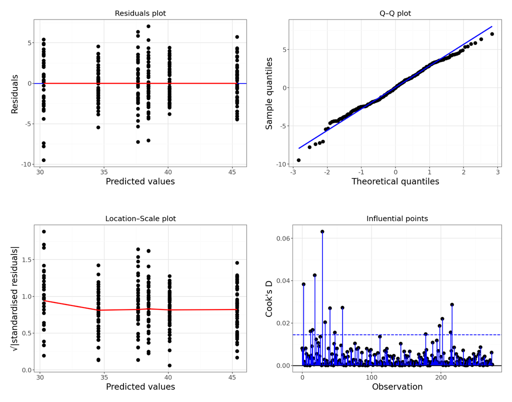

```python
dgplots(lm_auxin_py)
```

So, these actually all look pretty good, with the data looking normally distributed (**Q-Q plot**), linearity OK (**Residual plot**), homogeneity of variance looking sharp (**Location-scale plot**) and no clear influential points (**Influential points plot**).

#### Implement the test

Let’s carry out a two-way ANOVA:

```python
sm.stats.anova_lm(lm_auxin_py, typ = 2)
```

```
                                sum_sq     df           F        PR(>F)
C(genotype)                  83.839560    1.0   11.265874  9.033241e-04
concentration              4578.890410    2.0  307.642376  3.055198e-70
C(genotype):concentration  1034.894263    2.0   69.531546  4.558874e-25
Residual                   2001.872330  269.0         NaN           NaN
```

#### Interpret the output and report the results

There is definitely a significant interaction between `concentration` and `genotype`.

So, we can conclude the following:

> A two-way ANOVA showed that there is a significant interaction between genotype and auxin concentration on plant height (p = 4.56e-25). Increasing auxin concentration appears to result in a reduction of plant height in both wild type and mutant genotypes. The response in the mutant genotype seems to be less pronounced than in wild type.

### 11.8.1 Tulips

**ExerciseExercise 2**

Level:

Blooms and growing conditions

We’re sticking with the plant theme and using the `data/CS4-tulip.csv` data set, which contains information on an experiment to determine the best conditions for growing tulips (well someone has to care about these sorts of things!). The average number of flower heads (blooms) were recorded for 27 different plots. Each plot experienced one of three different watering regimes and one of three different shade regimes.

- Investigate how the number of blooms is affected by different growing conditions.

Note: have a look at the data and make sure that they are in the correct format!

**TipAnswer**

**R**

#### Load the data

```r
# read in the data
tulip <- read_csv("data/CS4-tulip.csv")
# have a quick look at the data
tulip
```

```
# A tibble: 27 × 3
   water shade blooms
   <dbl> <dbl>  <dbl>
 1     1     1    0
 2     1     2    0
 3     1     3  111.
 4     2     1  183.
 5     2     2   59.2
 6     2     3   76.8
 7     3     1  225.
 8     3     2   83.8
 9     3     3  135.
10     1     1   80.1
# ℹ 17 more rows
```

In this data set the watering regime (`water`) and shading regime (`shade`) are encoded with numerical values. However, these numbers are actually categories, representing the amount of water/shade.

As such, we don’t want to treat these as numbers but as *factors*. At the moment they are numbers, which we can tell with `<dbl>`, which stands for `double`.

We can convert the columns using the `as_factor()` function. Because we’d like to keep referring to these columns as factors, we will update our existing data set.

```r
# convert watering and shade regimes to factor
tulip <- tulip %>%
  mutate(water = as_factor(water),
         shade = as_factor(shade))
```

This data set has three variables; `blooms` (which is the response variable) and `water` and `shade` (which are the two potential predictor variables).

#### Visualise the data

As always we’ll visualise the data first:

```r
# by watering regime
ggplot(tulip,
       aes(x = water, y = blooms)) +
  geom_boxplot()
```

[figure not shown]

```r
# by shading regime
ggplot(tulip,
       aes(x = shade, y = blooms)) +
  geom_boxplot()
```

[figure not shown]

```r
# interaction plot by watering regime
ggplot(tulip,
       aes(x = shade,
           y = blooms,
           colour = water, group = water)) +
  stat_summary(fun = mean, geom = "point", size = 3) +
  stat_summary(fun = mean, geom = "line") +
  geom_jitter(alpha = 0.3, width = 0.1) +
  scale_colour_brewer(palette = "Dark2")
```

[figure not shown]

```r
# interaction plot by shade regime
ggplot(tulip,
       aes(x = water,
           y = blooms,
           colour = shade, group = shade)) +
  stat_summary(fun = mean, geom = "point", size = 3) +
  stat_summary(fun = mean, geom = "line") +
  geom_jitter(alpha = 0.3, width = 0.1) +
  scale_colour_brewer(palette = "Dark2")
```

[figure not shown]

Again, both interaction plots suggest that there might be an interaction here. Digging in a little deeper from a descriptive perspective, it looks as though that `water` regime 1 is behaving differently to `water` regimes 2 and 3 under different shade conditions.

#### Assumptions

First we need to define the model:

```r
# define the linear model
lm_tulip <- lm(blooms ~ water * shade,
               data = tulip)
```

Next, we check the assumptions:

```r
resid_panel(lm_tulip,
            plots = c("resid", "qq", "ls", "cookd"),
            smoother = TRUE)
```

[figure not shown]

These are actually all OK. A two-way ANOVA analysis is on the cards.

#### Implement the test

Let’s carry out the two-way ANOVA.

```r
# perform the ANOVA
anova(lm_tulip)
```

```
Analysis of Variance Table

Response: blooms
            Df Sum Sq Mean Sq F value    Pr(>F)
water        2 103626   51813 22.0542 1.442e-05 ***
shade        2  36376   18188  7.7417   0.00375 **
water:shade  4  41058   10265  4.3691   0.01211 *
Residuals   18  42288    2349
---
Signif. codes:  0 '***' 0.001 '**' 0.01 '*' 0.05 '.' 0.1 ' ' 1
```

#### Interpret the output and report results

So we do appear to have a significant interaction between `water` and `shade` as expected.

**Python**

#### Load the data

```python
# read in the data
tulip_py = pd.read_csv("data/CS4-tulip.csv")

# have a quick look at the data
tulip_py.head()
```

```
   water  shade  blooms
0      1      1    0.00
1      1      2    0.00
2      1      3  111.04
3      2      1  183.47
4      2      2   59.16
```

In this data set the watering regime (`water`) and shading regime (`shade`) are encoded with numerical values. However, these numbers are actually categories, representing the amount of water/shade.

As such, we don’t want to treat these as numbers but as *factors*. We can convert the columns using `astype(object)`. Because we’d like to keep referring to these columns as factors, we will update our existing data set.

```python
# convert watering and shade regimes to factor
tulip_py['water'] = tulip_py['water'].astype(object)
tulip_py['shade'] = tulip_py['shade'].astype(object)
```

This data set has three variables; `blooms` (which is the response variable) and `water` and `shade` (which are the two potential predictor variables).

#### Visualise the data

As always we’ll visualise the data first:

```python
# by watering regime
p = (ggplot(tulip_py,
        aes(x = "water", y = "blooms")) +
     geom_boxplot())

p.show()
```

[figure not shown]

```python
# by shading regime
p = (ggplot(tulip_py,
        aes(x = "shade", y = "blooms")) +
     geom_boxplot())

p.show()
```

[figure not shown]

```python
# interaction plot by watering regime
p = (ggplot(tulip_py,
        aes(x = "shade", y = "blooms",
            colour = "water", group = "water")) +
     stat_summary(fun_data = "mean_cl_boot",
                  geom = "point", size = 3) +
     stat_summary(fun_data = "mean_cl_boot",
                  geom = "line") +
     geom_jitter(alpha = 0.3, width = 0.1) +
     scale_colour_brewer(type = "qual", palette = "Dark2"))

p.show()
```

[figure not shown]

```python
# interaction plot by shade regime
p = (ggplot(tulip_py,
        aes(x = "water", y = "blooms",
            colour = "shade", group = "shade")) +
     stat_summary(fun_data = "mean_cl_boot",
                  geom = "point", size = 3) +
     stat_summary(fun_data = "mean_cl_boot",
                  geom = "line") +
     geom_jitter(alpha = 0.3, width = 0.1) +
     scale_colour_brewer(type = "qual", palette = "Dark2"))

p.show()
```

[figure not shown]

Again, both interaction plots suggest that there might be an interaction here. Digging in a little deeper from a descriptive perspective, it looks as though that `water` regime 1 is behaving differently to `water` regimes 2 and 3 under different shade conditions.

#### Assumptions

First we need to define the model:

```python
# create a linear model
model = smf.ols(formula= "blooms ~ water * shade", data = tulip_py)
# and get the fitted parameters of the model
lm_tulip_py = model.fit()
```

Next, we check the assumptions:

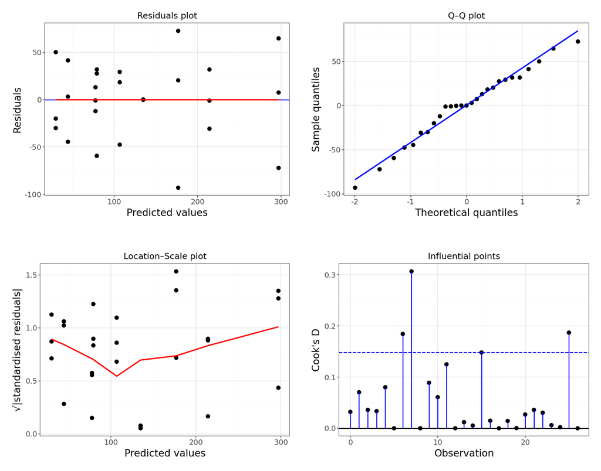

```python
dgplots(lm_tulip_py)
```

These are actually all OK. A two-way ANOVA analysis is on the cards.

#### Implement the test

Let’s carry out the two-way ANOVA.

```python
sm.stats.anova_lm(lm_tulip_py, typ = 2)
```

```
                    sum_sq    df          F    PR(>F)
water        103625.786985   2.0  22.054200  0.000014
shade         36375.936807   2.0   7.741723  0.003750
water:shade   41058.139437   4.0   4.369108  0.012108
Residual      42288.185200  18.0        NaN       NaN
```

#### Interpret the output and report results

So we do appear to have a significant interaction between `water` and `shade` as expected.

> A two-way ANOVA showed that there is a significant interaction between watering and shading regimes on number of blooms (p = 1.21e-02).

## 11.9 Summary

**TipKey points**

- A two-way ANOVA is used when there are two categorical variables and a single continuous variable
- We can visually check for interactions between the categorical variables by using interaction plots
- The two-way ANOVA is a type of linear model and assumes the following:
  1. the data have no systematic pattern
  2. the residuals are normally distributed
  3. the residuals have homogeneity of variance
  4. the fit does not depend on a single point (no single point has high leverage)